# Conceitos: Impacto, Fragilidade, Vulnerabilidade e Risco

Análise Ambiental · Aula 4.1

Prof. Dr. Luiz Diego Vidal Santos

## Abertura Visão Geral da Aula

Roteiro da aula Tópicos da Aula 4.1

- 1 Aspecto Ambiental, Impacto Ambiental e Poluição (Lei 6.938/1981 e CONAMA 01/1986)
- 2 Qualidade Ambiental, Degradação e Passivo Ambiental (Sánchez, 2020)
- 3 Resistência, Resiliência, Estabilidade e Capacidade de Suporte
- 4 Perigo, Suscetibilidade, Fragilidade, Vulnerabilidade e Risco ($R = P \times E \times V$)
- 5 Graus de Risco Urbano (R1 a R4 — PNPDEC Lei 12.608/2012 e IPT)
- 6 Preservação, Conservação, Mitigação, Recuperação, Reabilitação e Restauração

Objetivo da aula Rigor conceitual e normativo

Dominar com rigor técnico e legal o vocabulário conceitual da Análise Ambiental exigido na prática profissional do Geógrafo (EIA/RIMA, ZEE, PRAD, Cartas de Risco) e nos exames nacionais (ENADE e concursos para Analista Ambiental).

ABNT ISO 14001 PNMA 6.938/81 R = P × E × V Protocolo R1–R4

# Aspecto, Impacto, Poluição e Degradação

## Método Cadeia Causal: Causa (Aspecto) vs. Efeito (Impacto)

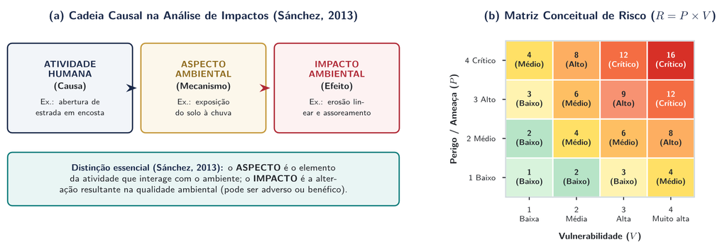

Cadeia causal na análise de impactos ambientais (Sánchez, 2013) e matriz conceitual de risco.

Cadeia Causal Aspecto–Impacto (ISO 14001 · Sánchez, 2013, 2020) e Matriz de Risco Distinção entre elemento da atividade que interage com o meio (Aspecto) e alteração resultante na qualidade ambiental (Impacto)

01 · Atividade Empreendimento

Implantação de rodovia ou loteamento em encosta.

02 · Aspecto Causa direta

Supressão de mata ciliar, impermeabilização ou efluente.

03 · Processo Mecanismo alterado

Aumento da enxurrada e perda de retenção de sedimentos.

04 · Impacto Alteração líquida

Assoreamento fluvial, perda de ictiofauna e cheias a jusante.

## Lei Definições Legais no Brasil (PNMA e CONAMA)

Lei 6.938/1981 · Art. 3º, II Degradação Ambiental

*Alteração adversa das características do meio ambiente* — categoria ampla que pode decorrer de processos naturais extremos ou de ações antrópicas.

Lei 6.938/1981 · Art. 3º, III Poluição

Degradação resultante de **atividades humanas** que prejudiquem saúde, segurança, bem-estar, biota, condições estéticas/sanitárias ou lancem matérias/energia em desacordo com padrões (ex.: CONAMA 357/2005 e 506/2024).

CONAMA 01/1986 · Art. 1º Impacto Ambiental

Alteração das propriedades físicas, químicas e biológicas do meio ambiente causada por matéria ou energia resultante de **atividades humanas** (pode ser **adverso** ou **benéfico**).

**Distinção em laudos técnicos:** toda poluição configura degradação ambiental, mas o conceito de impacto ambiental exige nexo causal antrópico e admite valoração positiva ou negativa.

## Método Dinâmica da Qualidade Ambiental ao Longo do Tempo

$$\text{Impacto}(t_1) = Q_{\text{com}}(t_1) - Q_{\text{sem}}(t_1)$$

Não é a simples diferença “antes vs. depois” ($Q_{t_1} - Q_{t_0}$): o impacto é a **diferença líquida** em $t_1$ entre a evolução **com** a ação humana ($Q_{\text{com}}$) e a projeção tendencial **sem** a ação ($Q_{\text{sem}}$ — linha de base dinâmica, Sánchez, 2020).

Responsabilidade acumulada Passivo Ambiental

Conjunto de obrigações legais, dívidas sociais e custos financeiros acumulados para reparar danos pretéritos não mitigados (ex.: solo contaminado, talude instável, déficit de Reserva Legal).

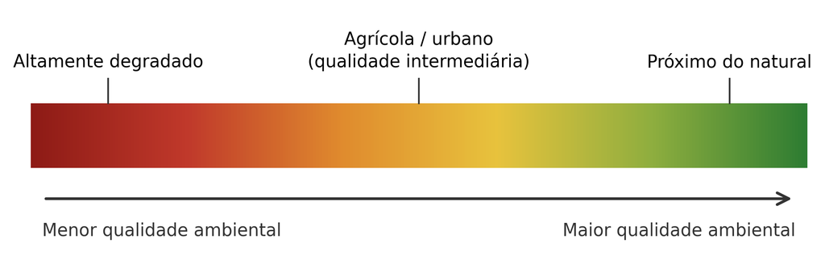

Escala de Qualidade Ambiental (Sánchez, 2020) Referencial contínuo entre ambientes altamente degradados e condições próximas do natural

# Estabilidade, Resiliência e Capacidade de Suporte

## Método Resistência, Resiliência e Limiares Críticos (Tipping Points)

**Inércia / Resistência (Holling, 1973):** capacidade de um sistema ambiental manter sua estrutura e funções inalteradas quando submetido a um tensor (distúrbio externo).

**Elasticidade / Resiliência:** velocidade e capacidade de o sistema **retornar ao estado de equilíbrio dinâmico** após cessar a perturbação, reorganizando seus fluxos.

**Limiar de Ruptura (*Tipping Point*):** limite crítico além do qual a degradação torna-se **irreversível na escala de tempo humana**, levando a um novo estado degradado (ex.: desertificação ou voçorocamento com rebaixamento freático).

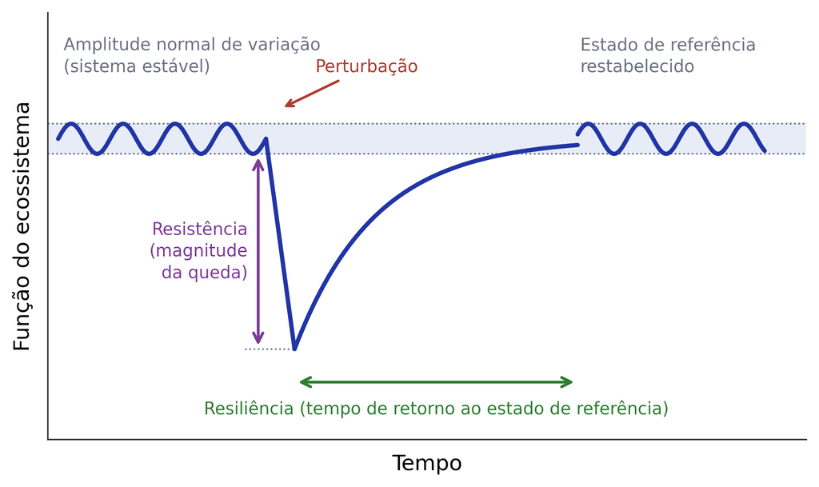

Comportamento de sistemas ambientais frente a tensores: resistência, resiliência e perda de estabilidade.

Resistência e Resiliência Frente a Tensores Magnitude da queda funcional sob perturbação e tempo de retorno ao estado de referência

## Método Capacidade de Suporte (Carrying Capacity)

**Definição operacional:** carga máxima de uso, extração de recursos ou lançamento de efluentes que um compartimento ambiental (bacia hidrográfica, aquífero, solo ou UC) suporta sem comprometer suas funções ecológicas e sua resiliência.

01 · Recursos Hídricos Autodepuração de rios

Carga máxima de $\text{DBO}_5$ ($\text{kg/dia}$) que o curso d’água dilui e oxida sem cair abaixo de Oxigênio Dissolvido $\text{OD} \ge 5\text{ mg/L}$ (Classe 2).

02 · Semiárido Suporte de pastagens

Taxa de lotação animal ($\text{UA/ha/ano}$) compatível com a fitomassa da Caatinga sem expor o solo à erosão laminar.

03 · Unidades de Conservação Carga turística (Cifuentes)

Limite de visitantes/dia em trilhas de UCs sem provocar compactação do solo ou afugentamento da fauna.

## Epistemologia Sustentabilidade Forte vs. Sustentabilidade Fraca

Economia Neoclássica · Solow Sustentabilidade Fraca

- **Premissa teórica:** o “capital natural” e o “capital construído/tecnológico” são perfeitamente substituíveis entre si.
- **Crítica geográfica:** ignora a irreversibilidade termodinâmica e funções ecossistêmicas vitais insubstituíveis.

Economia Ecológica · Daly; Georgescu-Roegen Sustentabilidade Forte

- **Premissa teórica:** o **capital natural crítico** (ciclo hidrológico, solos, biodiversidade, clima) é complementar e **insubstituível** pelo capital humano.
- **Aplicação legal:** base das restrições de **APPs**, **Unidades de Proteção Integral** e **enquadramento hídrico**.

A definição da capacidade de suporte parte da **Sustentabilidade Forte**: processos ecológicos críticos impõem tetos não negociáveis de intervenção.

# Perigo, Fragilidade, Vulnerabilidade e Risco

## Risco Equação Conceitual e Distinção Operacional

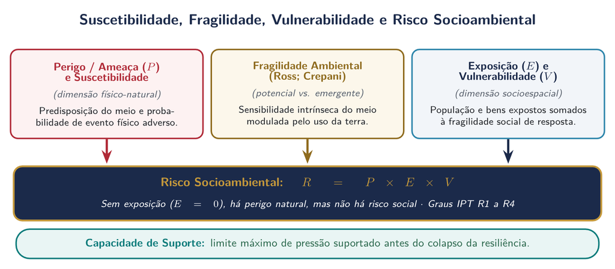

Distinção operacional entre Suscetibilidade, Perigo, Fragilidade Ambiental, Exposição, Vulnerabilidade e Risco Socioambiental.

Arquitetura Conceitual do Risco Socioambiental (R = P × E × V) Integração entre predisposição física (P e Fragilidade) e exposição/vulnerabilidade socioespacial (E e V)

Sem exposição ($E = 0$), existe perigo natural e suscetibilidade do terreno, mas **não há risco socioambiental**; a fragilidade (Ross; Crepani) modula a sensibilidade física pelo uso da terra.

## Risco Tabela Comparativa para Concursos e Laudos Técnicos

| Conceito | Natureza Dominante | Definição Exata | Exemplo Aplicado |
| --- | --- | --- | --- |
| **Suscetibilidade** | Físico-Natural (Intrínseca) | Propensão estática do terreno a desenvolver processo geodinâmico por litologia, relevo e solo. | Encosta com $38^\circ$ em Cambissolo raso sobre gnaisse fraturado. |
| **Perigo / Ameaça (*Hazard*)** | Físico-Temporal (Probabilística) | Probabilidade de ocorrência de fenômeno potencialmente danoso com dada magnitude e $TR$. | Chuva extrema de $120\text{ mm/24h}$ ($TR = 50\text{ anos}$) deflagrando escorregamento. |
| **Fragilidade Ambiental** | Ecodinâmica Integrada (Ross, 1994) | Instabilidade morfogenética natural (**Potencial**) combinada à proteção da cobertura (**Emergente**). | Classe 5 (Muito Forte) em vertente íngreme com Argissolo sob pastagem degradada. |
| **Vulnerabilidade** | Social, Institucional e Estrutural | Grau de incapacidade de resistir, lidar e se recuperar de um perigo (Cutter, 1996; Marandola & Hogan, 2005). | Famílias de baixa renda em autoconstruções sem arrimo, drenagem ou alerta. |
| **Risco ($R = P \times E \times V$)** | Socioambiental (Probabilidade de Perda) | Probabilidade de **danos humanos, materiais ou ambientais** quando $P$ incide sobre $E$ e $V$. | Setor de risco **R4 (Muito Alto)** com risco iminente de soterramento de moradias. |

## Risco Graus de Risco Urbano (MCidades / IPT / SGB-CPRM)

**R1 · Risco Baixo:** condicionantes geológico-geotécnicos e topográficos favoráveis; ausência de feições de instabilidade (trincas, degraus de abatimento, árvores inclinadas).

**R2 · Risco Médio:** condicionantes de média potencialidade; início de processos erosivos superficiais ou drenagem deficiente, sem evidências de ruptura iminente.

**R3 · Risco Alto:** condicionantes desfavoráveis (cortes verticais de talude, lançamento de águas servidas/fossas) e **feições de instabilidade significativas**; exige monitoramento e contenção.

**R4 · Risco Muito Alto:** movimentação ativa evidente (trincas no piso/paredes e terreno, embarrigamento de muros, cicatrizes frescas); maior criticidade no protocolo; requer avaliação urgente da Defesa Civil e medidas de proteção.

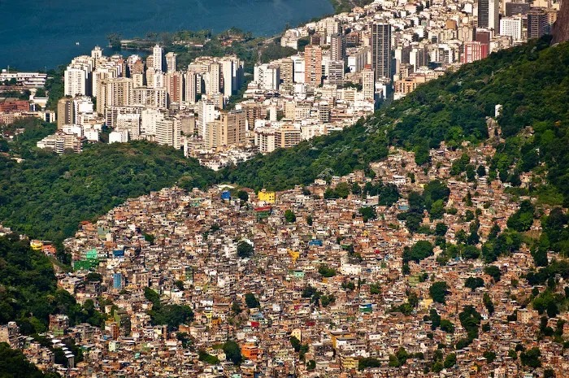

Ocupação residencial densa em encosta urbana íngreme em contraste com área urbana consolidada.

Segregação socioespacial e risco em encosta urbana Setorização R1–R4 (MCidades/IPT): exposição e vulnerabilidade concentram-se em taludes ocupados sem infraestrutura

## Campo Checklist de Campo: Instabilidade de Taludes (MCidades/IPT)

Indicador 01 · Morfometria e contexto Geometria da encosta

Avaliar inclinação, altura do corte, curvaturas, tipo de material e posição das edificações em relação à crista e à base do talude. **Nenhum limiar isolado define o grau de risco.**

A setorização integra geotecnia, hidrologia de drenagem e condições construtivas das moradias expostas.

Indicador 02 · Sinais de movimentação (Creep / Ruptura) Feições diagnósticas em vistoria

- Fendas de tração na crista do talude;
- Degraus de abatimento no terreno;
- Árvores, postes e cercas inclinados (“floresta bêbada”);
- Muros de contenção estufados (“embarrigados”) ou com drenos (*barbacãs*) entupidos;
- Surgência de água (exfiltração) na base do corte.

# Categorias de Intervenção Ambiental

## Lei Preservação, Conservação e Recomposição (SNUC · IN IBAMA 14/2024)

01 · Lei 9.985/2000 Preservação

Garantir **integridade e perenidade sem uso direto**. **Objetivo:** manter processos evolutivos. **Ex.:** ESEC, REBIO e APPs de nascentes.

02 · Lei 9.985/2000 Conservação

Manejo do uso humano com maior benefício atual e potencial futuro. **Objetivo:** conciliar produção e proteção. **Ex.:** Reserva Legal, FLONA, RESEX e SAFs.

03 · Licenciamento Mitigação

Medidas para **evitar, minimizar ou atenuar** impactos adversos previstos. **Objetivo:** reduzir dano na obra/operação. **Ex.:** bacias de decantação na terraplenagem.

04 · Uso futuro estável Reabilitação

Restitui **forma e função produtiva ou social estável**, distinta da original. **Objetivo:** estabilidade geotécnica e novo uso seguro. **Ex.:** cava de mineração convertida em parque/lago.

05 · Art. 2º, XIII, SNUC Recuperação

Restitui ecossistema degradado a **condição não degradada** (pode diferir da original). **Objetivo:** estabilidade morfodinâmica e edáfica. **Ex.:** voçoroca com paliçadas, retaludamento e cobertura mista.

06 · IN IBAMA 14/2024 Restauração Ecológica

Restitui o ecossistema **o mais próximo possível da condição original**. **Objetivo:** sucessão autossustentável nativa. **Ex.:** mata ciliar com alta diversidade regional da Caatinga/Mata Atlântica.

## Risco Aplicação: Do Perigo à Decisão Territorial

| Dimensão | Registro necessário em uma encosta ocupada |
| --- | --- |
| **Suscetibilidade** | Material, geometria, drenagem e processos que favorecem ruptura |
| **Perigo** | Processo, intensidade e possibilidade de ocorrência em um período |
| **Exposição** | Pessoas, moradias e infraestrutura no alcance do processo |
| **Vulnerabilidade** | Condições que ampliam perdas e dificultam a resposta |
| **Risco** | Integração dessas dimensões, com método explícito e incertezas |

O produto $P \times E \times V$ é uma representação conceitual: a quantificação exige unidades, probabilidades e funções de dano. A **Lei 12.608/2012** institui a PNPDEC; **R1–R4** pertencem aos protocolos técnicos de setorização.

# Síntese e Estudo Orientado nº 3

## Síntese Estudo Orientado nº 3 (Entrega na Aula 5.1)

Caso 1 · Urbano (Feira de Santana ou Salvador - BA) Cadeia de risco em área precária

Diferencie **Aspecto Ambiental**, **Processo**, **Impacto**, **Perigo**, **Vulnerabilidade** e **Risco** em uma ocupação residencial de baixa renda situada na planície de inundação de um córrego urbano ou em encosta de corte íngreme.

Caso 2 · Rural (Código Florestal e SNUC) Enquadramento de recomposição

Uma propriedade teve sua mata ciliar suprimida, gerando uma voçoroca ativa. Indique se a intervenção exigida pelo Código Florestal configura **reabilitação**, **recuperação** ou **restauração ecológica**, justificando com base na **Lei 9.985/2000** e na **Lei 12.651/2012**.

**Entrega na Aula 5.1:** resolva os dois estudos de caso analíticos articulando definição normativa, mecanismo físico e recorte territorial.

## Síntese Referências Bibliográficas

Marco legal e protocolos técnicos Legislação e setorização de risco

- BRASIL. **Lei nº 6.938, de 31 de agosto de 1981** (Política Nacional do Meio Ambiente).
- BRASIL. **Lei nº 9.985, de 18 de julho de 2000** (Sistema Nacional de Unidades de Conservação — SNUC).
- BRASIL. **Lei nº 12.608, de 10 de abril de 2012** (Política Nacional de Proteção e Defesa Civil — PNPDEC).
- CONAMA. **Resolução nº 01, de 23 de janeiro de 1986** (Critérios básicos e diretrizes gerais para a AIA).
- MINISTÉRIO DAS CIDADES; IPT. **Mapeamento de Riscos em Encostas e Margens de Rios**. Brasília: Ministério das Cidades; IPT, 2007.

Fundamentação teórico-metodológica Vulnerabilidade e Avaliação de Impacto

- CUTTER, S. L. Vulnerability to environmental hazards. **Progress in Human Geography**, v. 20, n. 4, p. 529–539, 1996.
- SÁNCHEZ, L. E. **Avaliação de Impacto Ambiental: conceitos e métodos**. 3. ed. São Paulo: Oficina de Textos, 2020.

Dominar a distinção precisa desses conceitos é requisito direto para EIA/RIMA, ZEE, PRAD, Cartas de Risco e concursos da área ambiental.